# ECO254 - Behavioral Economics

Professor: Simon Halliday

- Email/hangouts: shalliday+eco254@smith.edu Why is this my email address? Check [here](https://support.google.com/mail/answer/12096?hl=en)
- Syllabus
- [Project Guidelines](http://simondhalliday.github.io/eco254/fall_2015/team_project/team_guidelines)

## Week 14

### Tuesday 8 December:

- Go here: https://shalliday.shinyapps.io/sutter_shiny
- Import the data from your midterm and see whether you can create an interactive version of Figure 4 using the template provided.

## Week 13

### Thursday 3 December

- Project work; bring laptops and team spirit.

### Tuesday 1 December

- Bring your laptops. It’s team project time!
- We’ll also do the final experiment (other things equal)

## Week 12

### Tuesday 24 November

- We are going to to do an exercise with the World Values survey here: http://simondhalliday.github.io/eco254/fall_2015/activities/wvs/wvs
- And we’ll talk about Chapter 10.

## Week 11

### Tuesday 17 November

- We need to complete the Marseille exercise we didn’t get the chance to finish previously.

## Week 10

## Thursday 12 November

Go here for the initial Marseille guide:

- http://simondhalliday.github.io/eco254/fall_2015/activities/marseille/marseille

Download the descriptio of the data here:

- https://moodle.smith.edu/mod/resource/view.php?id=51529
- And the data itself as a .txt file here: https://moodle.smith.edu/mod/resource/view.php?id=51530

## Tuesday 10 November

## Week 9

## Week 8

### Thursday 29 October

- You can look at all the steps we’ll take with the Sutter data here: http://simondhalliday.github.io/eco254/fall_2015/activities/sutter/sutter_analysis_2
- We will look at the Wilcoxon test on Thursday as well as the a first attempt at a multiple regression model (my notes may change between now and then)
- We shall complete Chapter 5 (leaving out signalling games)
- Remember, I announced that we’ll exclude Ch. 6 and skip to Ch. 7

#### Experiment 3

- If we have time, we’ll do Experiment 3 (or I’ll leave the rest of Ch. 5 for next week).
- Go to VEconLab here: http://veconlab.econ.virginia.edu/login.htm

### Tuesday 27 October

- Be sure to have gone through the ggplot exercise that we started on last week Thursday.
- You can see my ‘readme.txt’ file here: http://simondhalliday.github.io/eco254/fall_2015/activities/sutter/readme.txt
- You can see a step-by-step completion of the first part of the exercise in R here: http://simondhalliday.github.io/eco254/fall_2015/activities/sutter/sutter_analysis
- Once we’ve completed this exercise, I’ll get started on Ch. 5 of Cartwright.
- Then we’ll spend a bit of time on group-work too.

`ggplot` exercise continued:

- you’re first going to need to make the data narrow using a key-value pair
- you’ll then need to filter out data that you don’t need for the first graph in the paper (i.e. you only want “teamtreat” and “individuals”)
  - to do this, you’ll need to use “logical operators”.
  - A logical operator is like an “and” sign “&”" or an “or” sign “|”
  - you’ll need to use or “|” because you’ll want to *keep* those observations in “teamtreat”" or “individual”
- once you’ve filtered out the treatments you don’t need, you can construct the ggplot code

Other Notes:

- Check here for the notes on Bayes’ Rule and understanding expected utility changes: simondhalliday.github.io/eco254/fall_2015/activities/bayes_rule/bayes_rule

## Week 7

### Thursday 22 October

We will talk about the following topics in R today:

- Wide vs. Narrow data: https://moodle.smith.edu/mod/resource/view.php?id=46463
- Joins: https://moodle.smith.edu/mod/resource/view.php?id=46462
- `group_by` and `summarise` see here: http://dtkaplan.github.io/DCF-2014/CourseNotes/BasicDataCommands/DraftNarrative.html and here: https://moodle.smith.edu/mod/resource/view.php?id=46744
- We will spend time on the team projects (we didn’t have time for this on Tues)
- I want you to emphasize the following steps:
  - making sure you have *data* to work with (to bring to later Thursday sessions)
  - deciding on the literature with which your project fits to produce a *literature review*
  - (much later) thinking about the ways in which you can alter/improve on the existing experiments/surveys to improve our overall knowledge

Notice, that once we have covered this content, we will have moved up to about Ch. 11 in *Data Computing*. I recommend that you read Chs. 9 through 11 if you want to keep up.

#### ggplot Exercise

We are going to do an exercise where we use ggplot to try to reproduce at least one graphic from a published paper. The paper is:

- Sutter, Matthias. 2009. “Individual Behavior and Group Membership: Comment.” American Economic Review, 99(5): 2247-57.
- download the paper from Moodle here: https://moodle.smith.edu/mod/resource/view.php?id=46730
- see the paper’s page at the AER here: https://www.aeaweb.org/articles.php?doi=10.1257/aer.99.5.2247&fnd=s
- download the data on Moodle here: https://moodle.smith.edu/mod/folder/view.php?id=46728
- see the online appendix for the paper here: https://www.aeaweb.org/aer/data/feb2013/20101542_app.pdf

Working with the data:

- You will notice that the data is *not* glyph-ready and it also isn’t that tidy.
- Ideally, we would work with the spreadsheet as is and import it into R. We’re not going to do that, but will create different spreadsheets with different data and *then* import them into R.
- Check out the Tier protocol for suggestions.
- Put the original data in an ‘original data’ folder.
- Then create a folder with ‘Working data’
- We will use the data in working data and document what we do in a readme.txt file.

Also, check out these links for behavioral econ in the press:

- People don’t want equality, they want fairness: http://www.theatlantic.com/science/archive/2015/10/people-dont-actually-want-equality/411784/
- Cass Sunstein reviews Akerlof and Shiller’s *Phishing for Phools*: http://www.nybooks.com/articles/archives/2015/oct/22/why-free-markets-make-fools-us/

### Tuesday 20 October

We will do the following:

- continue with Time chapter
- spend time working on the class exercise to generate graphs for risk averse, risk-loving and risk neutral actors

## Week 6

### Thursday 15 October

- We will briefly polish one idea from Risk
- We begin Time Preferences (ch. 4)
- We will read a short article
- I hope to show you something new in R very briefly

## Week 5

### Tuesday 6 October

- We continue with Chapter 3 (Risk)

### Thursday 8 October

We’ll be doing an R lab today (followed by a quiz online for hand-in the following week).

- Don’t forgot to hand in your exercises due today! Hand in on Moodle.
- Here’s the lab: http://simondhalliday.github.io/eco254/fall_2015/Labs/Lab2/Lab2

Notes:

- Slides on glyph-ready data: https://moodle.smith.edu/mod/resource/view.php?id=43766
- Slides on using ggplot: https://moodle.smith.edu/mod/resource/view.php?id=43768

## Week 4

### Thursday 1 October

- We’re doing Experiment 2 today.
- Go to VEconLab here: http://veconlab.econ.virginia.edu/login.htm
- I will give you details on this page that you can use to log in.
- Check out the set of exercises for Chapters 1 to 4 of *Data Computing* here: simondhalliday.github.io/eco254/fall_2015/exercises/exercises1-4 The exercises will be due online on Moodle on 8 October.
- The graphic from the experiment is here: https://moodle.smith.edu/mod/resource/view.php?id=42294
- Here is data from the set of lotteries you chose: https://moodle.smith.edu/mod/resource/view.php?id=42295
- Here is the data from the short second experiment: https://moodle.smith.edu/mod/resource/view.php?id=42296
- I strongly recommend that you read Chapters 4 and 7 of the Charles Plott book as it covers the relevant content for these (and does some of it better than the Cartwright book in my mind)

### Tuesday 29 September

- Be sure to complete the first R quiz here: https://moodle.smith.edu/mod/quiz/view.php?id=39737
- We will start on Chapter 3 in class. Please make sure you’re signed up for topics to discuss in class.

## Week 3

### Tuesday 22 September

- Finish chapter two’s content from 2.3 onwards.

### Thursday 24 September

We shall talk about Chs 2-4 of Data Computing and get started on a lab:

- http://simondhalliday.github.io/eco254/fall_2015/Labs/Lab1/Lab1
- If you need to check the cheat sheets, then there are links lower down the page.
- R command structure: https://moodle.smith.edu/mod/resource/view.php?id=39615
- Data verbs: https://moodle.smith.edu/mod/resource/view.php?id=39616

## Week 2

### Tuesday 15 September

Be sure to read Chapter 2 (I would suggest to the end of 2.5 in Cartwright).

- Here’s a link to the workbook from class on the happiness scale: simondhalliday.github.io/eco254/fall_2015/activities/happy_students
- The reading guide is available here: docs.google.com/document/d/12SU6upZrKDtUwyNaWOATo3LIzRjT3yODHkUlag5Hgu0/edit
- The article we read at the end of class, Larcom et al (15 September 2015), ‘The Benefits of Forced Experimentation’, is available here: www.voxeu.org/article/benefits-forced-experimentation

### Thursday 17 September

We will use these documents as guides, for some of them you will need to log in to Moodle:

- Installation Guide: https://moodle.smith.edu/mod/resource/view.php?id=37210
- Tidy Data: fall_2015/slides/tidy_data
- Check your name off here: https://docs.google.com/spreadsheets/d/1DB60SzS9VBA1IsUr2AiPWJyt0f3C6RyLbcSstSWvCWw/edit?usp=sharing

Watch these videos by Nick Horton (Amherst) as an introduction to R markdown:

- Video 1: www.youtube.com/watch?v=w4hLT7WyjnM&feature=youtu.be
- Video 2: www.youtube.com/watch?v=MdxNFiXm1qE&feature=youtu.be

Prof Horton also has some videos about starting out with R:

- Video 1: www.youtube.com/channel/UC5fHtS-LUBTBWI9_h7eCcRQ
- Video 2: www.youtube.com/watch?v=3Y_i3PxIKfg

## Week 1

### Thursday 10 September

Today we shall do an experiment and (if there’s time) begin to talk about using R.

- Go to VEconLab here: http://veconlab.econ.virginia.edu/login.htm
- I will give you details on this page that you can use to log in.

Experiment Reports

- Guidelines for the reports are available here: simondhalliday.github.io/eco254/fall_2015/Admin/exp_reports
- The graph from the experiment is here: drive.google.com/file/d/0B17bVUW1HMv-cUhfNkItNjlfU00/view?usp=sharing
- The data are available in a google spreadsheet here: docs.google.com/spreadsheets/d/10xzCd49nOEMDbxmegCfBaFZLz1uYE0ry7zGMBljEUcg/edit?usp=sharing
- The data currently have a ‘filter’ in the first row and they are filtered on the individual ID codes (1 through 28). You can find your ID code and use the ID code to check what behavior you adopted, i.e. your bid or ask. Your cumulative earnings are also recorded.
- Screenshots of the instructions are available in a zipped file here: drive.google.com/file/d/0B17bVUW1HMv-Vk9PUjZ3WUhlS0U/view?usp=sharing.
- [Research Reports with R Markdown Prezi](http://prezi.com/8pwudebf9jof/reproducible-20/)
- Markdown Demo File (.html)
- Markdown Demo File (.Rmd)

### Tuesday 8 September

Results of in-class question about behavioral economics:

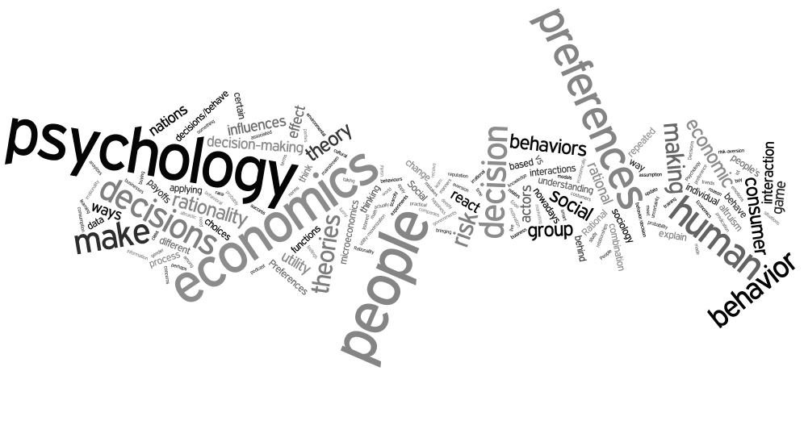

*Homework*

On your laptop, follow these steps to install R and the latest version of RStudio. Make sure to install R first!

1. Download and install R here: cran.rstudio.com/
2. Download and install Rstudio here: www.rstudio.com/products/rstudio/download/

Complete these surveys:

- Your individual background and preferences: goo.gl/forms/M9DaKh366j
- Questions about your thinking and preferences: goo.gl/forms/MKPML7aMny
- Moodle statistical knowledge survey: moodle.smith.edu/mod/questionnaire/view.php?id=17318
- Short Reading (if an article is blocked in your browser, search for the title using Google).
  - [Economics Behaving Badly](http://www.nytimes.com/2010/07/15/opinion/15loewenstein.html), Loewenstein and Ubel, *New York Times*, 14 July 2010.
  - [New Truths that only one can see](http://www.nytimes.com/2014/01/21/science/new-truths-that-only-one-can-see.html), *New York Times*, George Johnson, 20 January 2014.
  - [How reliable are psychology studies?](http://www.theatlantic.com/health/archive/2015/08/psychology-studies-reliability-reproducability-nosek/402466/), Ed Yong, *The Atlantic*, 27 August 2015.
  - [Unreliable Research: trouble at the lab](http://www.economist.com/news/briefing/21588057-scientists-think-science-self-correcting-alarming-degree-it-not-trouble), *The Economist*, 17 October 2013.
  - [Austerity’s Spreadsheet Error](http://thecolbertreport.cc.com/videos/dcyvro/austerity-s-spreadsheet-error) (Colbert Report Video)

### R Cheat Sheets

- `ggplot2` and data visualization cheat sheet: www.rstudio.com/wp-content/uploads/2015/03/ggplot2-cheatsheet.pdf
- data wrangling with `dplyr` cheat sheet: www.rstudio.com/wp-content/uploads/2015/02/data-wrangling-cheatsheet.pdf
- “minimal R” for basic stats in R (with `mosaic`, by Randy Pruim - we use pages 3-4 mostly): cran.r-project.org/web/packages/mosaic/vignettes/MinimalR.pdf
- R Markdown cheat sheet: www.rstudio.com/wp-content/uploads/2015/02/rmarkdown-cheatsheet.pdf
- R markdown reference guide (more comprehensive & assumes more knowledge of, e.g. html): www.rstudio.com/wp-content/uploads/2015/03/rmarkdown-reference.pdf

### Suggestions for your research project

Go to the following page: simondhalliday.github.io/eco254/fall_2015/team_project/team_guidelines

### Topic Presentation Sign-ups:

- Chapter 2: docs.google.com/spreadsheets/d/1EkJAaEIILjh__vaD5rZpRPgUOn_bYXPoU24v8kks5TE/edit?usp=sharing.
- Chapter 3: [docs.google.com/spreadsheets/d/1Vd6Q–wh-Cuwpa0dZOY0DlxIp-hoDyUiXFWInNX4kfE/edit?usp=sharing](https://docs.google.com/spreadsheets/d/1Vd6Q--wh-Cuwpa0dZOY0DlxIp-hoDyUiXFWInNX4kfE/edit?usp=sharing)
- Chapter 4: docs.google.com/spreadsheets/d/1fg424AeOBNTP-mTB0Ldf8u6YGcQhGwluI6x4q8MnkCA/edit?usp=sharing
- Chapter 5: docs.google.com/spreadsheets/d/1FiIqjgV7PcmNJIh0-oRoOxLf5g_y0DTXnvS-jwj2Mr0/edit?usp=sharing
- Chapter 6: docs.google.com/spreadsheets/d/14fd-eZ84u526MVMlWknqkD7Ev8CjPQRbzw3t_17TYkA/edit?usp=sharing
- Chapter 7: [docs.google.com/spreadsheets/d/15CUugzKfJzTdPokWKUNMO1pO98sb2TnMWhh19I–UBA/edit?usp=sharing](https://docs.google.com/spreadsheets/d/15CUugzKfJzTdPokWKUNMO1pO98sb2TnMWhh19I--UBA/edit?usp=sharing)
- Chapter 10: docs.google.com/spreadsheets/d/1RICCHlaLvAyizkmopurDIov-8hxrApuTMYRqcViWM8Y/edit?usp=sharing
- Chapter 11: docs.google.com/spreadsheets/d/1eX6sUfrrvuI4btyEbUuyy-qx-UmC0qAGWhK0WklIvaA/edit?usp=sharing

### Chapter shared notes

Each person presenting on a given topic should add their notes/definitions in each shared chapter note section. Other people may add to these notes.

- Chapter 2: [docs.google.com/document/d/1mOkEsD59_JuuevBZfO4kfCDtdAepEz-a3HOjo2xz–s/edit?usp=sharing](https://docs.google.com/document/d/1mOkEsD59_JuuevBZfO4kfCDtdAepEz-a3HOjo2xz--s/edit?usp=sharing)
- Chapter 3: docs.google.com/document/d/1gysWaBqK3j8f2KvIj8B1kkk3VDp3172L4zO1vXNb1Es/edit?usp=sharing
- Chapter 4: docs.google.com/document/d/1ck6LHxiOVMzmQMLagcj6tFyNTVVr_vUmibf6JdAjcqw/edit?usp=sharing
- Chapter 5: docs.google.com/document/d/1pdYt-uC6g80N0wMuuWPa3krqM_GqKLzDuN7n-_Lbaos/edit?usp=sharing
- Chapter 6: docs.google.com/document/d/15hWodfWxqaaRjwtMjMeHA5yKWohttswOvj1gY3Lqkc0/edit?usp=sharing
- Chapter 7: docs.google.com/document/d/1uBgu2o55ZlOZR2E7CiCj9XX2VdEcUH3krMmLJ3jl38Y/edit?usp=sharing
- Chapter 10: docs.google.com/document/d/1ev6fNTCR3iVq8szAjE-GggGAXwTabD0da4_NoCwFHco/edit?usp=sharing
- Chapter 11: docs.google.com/document/d/1v73QYA8-CtsIvTCQC3PrRO73G165bijfFSsi3qtek6A/edit?usp=sharing

### Chapter Questions and Definitions

- Chapter 2: docs.google.com/document/d/1237o0s9GHzibZsZLTEKUY1_pQmOhVycnj8yOwCRQFis/edit?usp=sharing
- Chapter 3:
- Chapter 4:
- Chapter 5:
- Chapter 6:
- Chapter 7:
- Chapter 10:
- Chapter 11: